# AI - CA2 - 810196678

همانطور که مشخص است در این پروژه قصد آموزش دادن برنامه برای تشخیص ایمیل های اسپم را داریم. برای این منظور ابتدا با بررسی حالات و مشخصات مختلف بهترین ویژگی ها برای بررسی و تشخیص ایمیل اسپم را پیدا می کنیم و سپس الگوریتم مربوط به آن را پیاده سازی می کنیم. برای جلوگیری از اووِرفیت راه حل معمول آن را در پیش خواهیم گرفت به این صورت که ۴/۵ از دیتایی که در اختیار داریم را به عنوان دیتای تِرِین مورد بررسی قرار می دهیم (که آن ها را جدا کرده و در فایل اکسل تِرِین ذخیره کردیم) و ۱/۵ دیتای باقیمانده را برای بررسی اوورفیت نگه خواهیم داشت (در فایل اکسل تست).

پس از آنکه الگوریتم مورد قبول را پیدا کردیم آن را در فایل جداگانه ای بازنویسی خواهیم کرد و از هر ۵۰۰۰ دیتا آموزش خواهیم داد و از آن برای دریافت خروجی استفاده می کنیم. این فایل در پوشه ی کد قرار خواهد گرفت.

ابتدا نیاز داریم کتابخانه های مورد نیازمان را فراهم کنیم و دیتای تِرِین را لود کنیم.

```python
from pandas import DataFrame, read_csv
import pandas as pd
from nltk.stem.wordnet import WordNetLemmatizer
from pattern3.text.en import singularize
import matplotlib.pyplot as plt
import math
import re

file = './data/train.csv'
Data = pd.read_csv(file)

emails = Data['text']
statuses = Data['type']
emailsNumber = len(emails)
```

اولین ویژگی بارزی که مورد بررسی قرار خواهیم داد وجود یا عدم وجود لینک اینترنتی در ایمیل است. دلیل انتخاب این ویژگی معقول بودن حضور حداکثری آن در ایمیل های تبلیغاتی است.

تابعی برای تشخیص وجود یا عدم وجود لینک در یک ایمیل پیاده سازی کردیم.

```python
def hasLink(email) :
    links = []
    links += re.findall('www\.(?:[-\w.]|(?:%[\da-fA-F]))+', email)
    links += re.findall('https?://(?:[-\w.]|(?:%[\da-fA-F]))+', email)
    links += re.findall('[-\w.]?\.com', email)
    return 1 if (len(links) != 0) else 0

emailHasLinks = [hasLink(email) for email in emails]
```

در آرایه ای متناظر با ایمیل ها این ویژگی را برای آن ها ثبت می کنیم.

دومین ویژگی مورد بررسی نیز وجود شماره ی بلند (شماره ی تماس - شماره ی حساب - قیمت و ..) خواهد بود که دلیلی مشابه دلیل بیان شده برای لینک ارد. درستی این ویژگی ها را برای تشخیص جلوتر بررسی می کنیم.

```python
def hasLongNumber(email) :
    return 1 if len(re.findall('[0-9\-]{3}', email)) != 0 else 0

emailHasLongNumber = [hasLongNumber(email) for email in emails]
```

ایمیل هایی که در اختیار داریم بیش از اندازه بی نظم و غیرقابل تحلیل اند پس تغییرات زیر را بر روی آنها اعمال می کنیم:

1- تمام کاراکتر های آنها را به کاراکتر های حروف کوچک زبان انگلیسی تبدیل می کنیم.

۲- کاراکتر های غیر حروف لاتین را با فضای خالی جایگزین می کنیم.

قبل از آن که تغییرات بالا اعمال شوند بد نیست تعداد کاراکتر های غیر حروف لاتینی که حذف می کنیم را نیز ثبت می کنیم شاید که در اسپم بودن تاثیر گذار باشند. برای ثبت این مورد وزن این کاراکتر ها را در هر ایمیل ثبت می کنیم:

```python
trashCharsWeights = [0 for i in range(emailsNumber)]

for index in range(emailsNumber) :
    email = emails[index].lower()
    formedEmail = ""
    for character in email :
        if character >= 'a' and character <= 'z' :
            formedEmail += character
        else :
            formedEmail += ' '
            trashCharsWeights[index] += 1
    trashCharsWeights[index] /= len(emails[index].split()) if trashCharsWeights[index] != 0 else 1
    emails[index] = formedEmail
```

بهتر است محتوای ایمیل های اسپم و غیراسپم را در دو فضای جداگانه ذخیره کنیم تا بهتر متوجه تاثیر ویژگی ها باشیم. پس آرایه ی ایمیل ها و تمام ویژگی هایی که تا این لحظه ثبت کردیم را به دو بخش اسپم و غیر اسپم تقسیم می کنیم.

```python
hamEmails = []
spamEmails = []
hamTrashCharsWeights = []
spamTrashCharsWeights = []
hamHasLinks = []
spamHasLinks = []
hamHasLongNumber = []
spamHasLongNumber = []

for index in range(emailsNumber) :
    if statuses[index] == 'spam' :
        spamEmails.append(emails[index])
        spamTrashCharsWeights.append(trashCharsWeights[index])
        spamHasLinks.append(emailHasLinks[index])
        spamHasLongNumber.append(emailHasLongNumber[index])
    else :
        hamEmails.append(emails[index])
        hamTrashCharsWeights.append(trashCharsWeights[index])
        hamHasLinks.append(emailHasLinks[index])
        hamHasLongNumber.append(emailHasLongNumber[index])

hamsNumber = len(hamEmails)
spamsNumber = len(spamEmails)
```

حال که ویژگی های مذکور را در دو دسته ی جداگانه داریم بهتر می توانیم تاثیر ویژگی ها را مشاهده کنیم. برای این کار نمودار مربوط به هرکدام از ویژگی ها را رسم می کنیم.

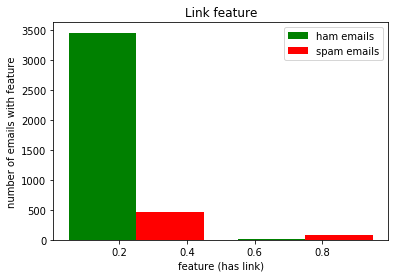

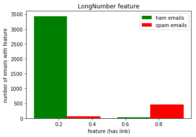

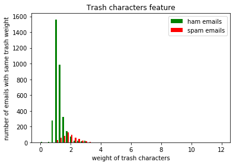

```python
plt.hist([hamHasLinks,spamHasLinks], 2, color = ['g','r'], label = ['ham emails','spam emails'])
plt.title('Link feature')
plt.xlabel('feature (has link)')
plt.ylabel('number of emails with feature')
plt.legend()
plt.show()

plt.hist([hamHasLongNumber,spamHasLongNumber], 2, color = ['g','r'], label = ['ham emails','spam emails'])
plt.title('LongNumber feature')
plt.xlabel('feature (has link)')
plt.ylabel('number of emails with feature')
plt.legend()
plt.show()

plt.hist([hamTrashCharsWeights,spamTrashCharsWeights], 50, color = ['g','r'], label = ['ham emails','spam emails'])
plt.title('Trash characters feature')
plt.xlabel('weight of trash characters')
plt.ylabel('number of emails with same trash weight')
plt.legend()
plt.show()
```

برای اعمال تاثیر هر ویژگی بر احتمال نهایی اسپم بودن باید احتمال اسپم بودن هر ایمیل با توجه به تاثیر منفرد هر ویژگی را محاسبه کنیم. برای این کار از قضیه ی بیز استفاده می کنیم. پس فرمول بیز را برای هر ویژگی به صورت جداگانه می نویسیم و احتمال های مربوطه را محاسبه می کنیم. برای اطمینان از بازده درست این احتمال ها نمودار آن ها را هم رسم و بررسی می کنیم:

```python
def linkBayesian(feature) :
    P_spam = spamsNumber/(spamsNumber+hamsNumber)
    numberOfHamsWithLiks = hamHasLinks.count(1)
    numberOfSpamsWithLiks = spamHasLinks.count(1)
    spamEmailsWithFeature = numberOfSpamsWithLiks if feature else spamsNumber - numberOfSpamsWithLiks
    hamEmailsWithFeature = numberOfHamsWithLiks if feature else hamsNumber - numberOfHamsWithLiks
    P_feature_if_spam = spamEmailsWithFeature / spamsNumber
    P_feature_if_ham = hamEmailsWithFeature / hamsNumber
    P_feature = P_feature_if_spam + P_feature_if_ham
    return 100*(P_feature_if_spam*P_spam/P_feature) if P_feature != 0 else 0
```

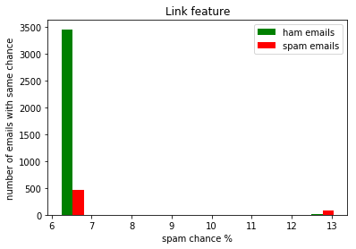

```python
hamLinkBayesianPs = [linkBayesian(feature) for feature in hamHasLinks]
spamLinkBayesianPs = [linkBayesian(feature) for feature in spamHasLinks]

plt.hist([hamLinkBayesianPs,spamLinkBayesianPs], 10, color = ['g','r'], label = ['ham emails','spam emails'])
plt.title('Link feature')
plt.xlabel('spam chance %')
plt.ylabel('number of emails with same chance')
plt.legend()
plt.show()
```

پس احتمال خروجی قابل قبول است.

```python
def longNumberBayseian(feature) :
    P_spam = spamsNumber/(spamsNumber+hamsNumber)
    numberOfHamsWithLongNumber = hamHasLongNumber.count(1)
    numberOfSpamsWithLongNumber = spamHasLongNumber.count(1)
    spamEmailsWithFeature = numberOfSpamsWithLongNumber if feature else spamsNumber - numberOfSpamsWithLongNumber
    hamEmailsWithFeature = numberOfHamsWithLongNumber if feature else hamsNumber - numberOfHamsWithLongNumber
    P_feature_if_spam = spamEmailsWithFeature / spamsNumber
    P_feature_if_ham = hamEmailsWithFeature / hamsNumber
    P_feature = P_feature_if_spam + P_feature_if_ham
    return 100*(P_feature_if_spam*P_spam/P_feature) if P_feature != 0 else 0
```

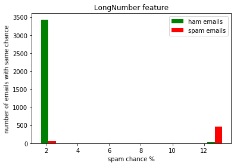

```python
hamLongNumberBayesianPs = [longNumberBayseian(feature) for feature in hamHasLongNumber]
spamLongNumberBayesianPs = [longNumberBayseian(feature) for feature in spamHasLongNumber]

plt.hist([hamLongNumberBayesianPs,spamLongNumberBayesianPs], 10, color = ['g','r'], label = ['ham emails','spam emails'])
plt.title('LongNumber feature')
plt.xlabel('spam chance %')
plt.ylabel('number of emails with same chance')
plt.legend()
plt.show()
```

پس احتمال خروجی قابل قبول است. این احتمال از احتمال خروجی ویژگی لینک عملکرد بهتری دارد.

```python
def trashCharBayesian(feature) :
    P_spam = spamsNumber/(spamsNumber+hamsNumber)

    spamEmailsWithFeature = 0
    for spamTrashCharsWeight in spamTrashCharsWeights :
        if spamTrashCharsWeight >= feature:
            spamEmailsWithFeature += 1

    hamEmailsWithFeature = 0
    for hamTrashCharsWeight in hamTrashCharsWeights :
        if hamTrashCharsWeight >= feature:
            hamEmailsWithFeature +=  1

    P_feature_if_spam = spamEmailsWithFeature / spamsNumber
    P_feature_if_ham = hamEmailsWithFeature / hamsNumber
    P_feature = P_feature_if_spam + P_feature_if_ham
    return 100*(P_feature_if_spam*P_spam/P_feature) if P_feature != 0 else 0
```

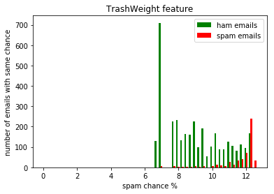

```python
hamTrashWeightsBayesianPs = [trashCharBayesian(feature) for feature in hamTrashCharsWeights]
spamTrashWeightsBayesianPs = [trashCharBayesian(feature) for feature in spamTrashCharsWeights]

plt.hist([hamTrashWeightsBayesianPs,spamTrashWeightsBayesianPs], 50, color = ['g','r'], label = ['ham emails','spam emails'])
plt.title('TrashWeight feature')
plt.xlabel('spam chance %')
plt.ylabel('number of emails with same chance')
plt.legend()
plt.show()
```

پس این احتمال نیز قابل استفاده است.

گرچه این ویژگی ها تاثیر خوبی دارند اما برای رای نهایی کافی نیستند. ویژگی بعدی که بررسی می کنیم طول ایمیل هاست:

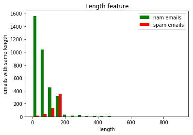

```python
hamLengths = [len(email) for email in hamEmails]
spamLengths = [len(email) for email in spamEmails]

plt.hist([hamLengths, spamLengths], 20, color = ['g','r'], label = ['ham emails','spam emails'])
plt.title('Length feature')
plt.xlabel('length')
plt.ylabel('emails with same length')
plt.legend()
plt.show()
```

با توجه به نمودار این ویژگی تاثیر مثبت آن کمی ابهام دارد اما خوب است که نمودار احتمال های مربوط به آن را نیز رسم کنیم تا تاثیر نهایی آن را مشاهده کنیم. با توجه به مجتمع بودن توزیع این ویژگی در ناحیه ای خاص برای ایمیل های اسپم شاید تاثیر مثبتی داشته باشد:

```python
def lengthBayesian(feature) :
    P_spam = spamsNumber/(spamsNumber+hamsNumber)

    spamEmailsWithFeature = 0
    for length in spamLengths :
        if abs(feature - length) <= 1 :
            spamEmailsWithFeature += 1

    hamEmailsWithFeature = 0
    for length in hamLengths :
        if abs(feature - length) <= 1 :
            hamEmailsWithFeature += 1

    P_feature_if_spam = spamEmailsWithFeature / spamsNumber
    P_feature_if_ham = hamEmailsWithFeature / hamsNumber
    P_feature = P_feature_if_spam + P_feature_if_ham
    return 100*(P_feature_if_spam*P_spam/P_feature) if P_feature != 0 else 0
```

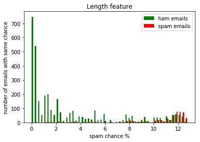

```python
hamLengthBayesianPs = [lengthBayesian(feature) for feature in hamLengths]
spamLengthBayesianPs = [lengthBayesian(feature) for feature in spamLengths]

plt.hist([hamLengthBayesianPs,spamLengthBayesianPs], 50, color = ['g','r'], label = ['ham emails','spam emails'])
plt.title('Length feature')
plt.xlabel('spam chance %')
plt.ylabel('number of emails with same chance')
plt.legend()
plt.show()
```

این خرجی گرچه بازده چشم گیری ندارد اما باز هم با توجه به توضیع احتمال ها می تواند کمک کند. پس از این ویژگی نیز استفاده خواهیم کرد.

یک ویژگی دیگر که اضافه خواهیم کرد کمی پیچیده تر است. با توجه به تکرار هر کلمه در ایمیل های اسپم و غیر اسپم برای هر لغت ارزشی تعیین می شود که برابر خواهد بود با تکرار در ایمیل های غیراسپم منهای تکرار در ایمیل های اسپم. اما با توجه به ناعادلانه بودن تعداد ایمیل های اسپم و غیر اسپم بهتر است بجای تعداد تکرار این مقدار را تقسیم بر تعداد ایمیل های هر دسته کنیم و ارش گذاری را انجام دهیم.

برای این ارزش گذاری لغات جمع - مفرد و همینطور افعال از مصدر مشترک را یکی درنظر می گیریم:

```python
wordsValue = dict()
wordsRepeat = dict()

def updateWordsValue(emails, status) :
    for email in emails :
        for word in email.split() :
            if len(word) < 2 : continue
            word = WordNetLemmatizer().lemmatize(word,'v')
            word = singularize(word)
            if word not in wordsValue :
                wordsValue[word] = 0
                wordsRepeat[word] = 0
            wordsValue[word] += 1/hamsNumber if status == 'ham' else -1/spamsNumber
            wordsRepeat[word] += 1

updateWordsValue(hamEmails, 'ham')
updateWordsValue(spamEmails, 'spam')
```

حال می توانیم قبل از ادامه دادن به پیاده سازی ویژگی موردنظر ابتدا لغات پرتکرار را حذف کنیم:

```python
commonWords = set()
commonWordsEdge = emailsNumber/10

for word,value in wordsRepeat.items() :
    if value > commonWordsEdge :
        commonWords.add(word)
print(commonWords)

# for word in commonWords :
#     wordsValue.pop(word)
```

```
{'go', 'my', 'get', 'the', 'be', 'you', 'of', 'for', 'and', 'ymy', 'it', 'call', 'that', 'have', 'in', 'do', 'me', 'to'}
```

همانطور که مشاهده می شود لغات پرتکرار به صورت معقولی تشخیص داده شده اند. فقط لغت ymy غیر طبیعی است که اگر لغات پرتکرار فقط در ایمیل های غیر اسپم را بررسی می کردیم این گزینه را نمی دیدیم. اما به هر طریق با آزمون و خطاهایی که در طول پروژه انجام شد حذف این لغات تاثیر نامطلوبی داشت پس از این عمل صرف نظر می کنیم.

حال به ارزش گذاری ایمیل ها با توجه به ارش لغاتشان می پردازیم. ارزش هر ایمیل مصادف خواهد بود با میانگیر ارزش لغاتش. با توجه به تعریف ما از ارزش هر لغت درمی یابیم که منفی تر بودن این ویژگی نشانه ی اسپم تر بودن است. این موضوع را بر روی نمودار ها بررسی خواهیم کرد:

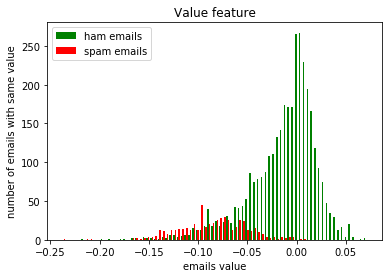

```python
def setEmailsValue(emails) :
    values = []
    for email in emails :
        value = 0
        wordsProcessNumber = 0
        for word in email.split() :
            word = WordNetLemmatizer().lemmatize(word,'v')
            word = singularize(word)
            if word not in wordsValue : continue
            value += wordsValue[word]
            wordsProcessNumber += 1
        value /= wordsProcessNumber if wordsProcessNumber != 0 else 1
        values.append(value)
    return values

hamValues = setEmailsValue(hamEmails)
spamValues = setEmailsValue(spamEmails)

plt.hist([hamValues,spamValues], 80, color = ['g','r'], label = ['ham emails','spam emails'])
plt.title('Value feature')
plt.xlabel('emails value')
plt.ylabel('number of emails with same value')
plt.legend()
plt.show()
```

همانطور که انتظار داشتیم این ویژگی انتظار ما را به خوبی برآورده می کند و می توانیم از احتمال آن استفاده کنیم:

```python
def valueBayesian(feature) :
    P_spam = spamsNumber/(spamsNumber+hamsNumber)

    spamEmailsWithFeature = 0
    for value in spamValues :
        if value <= feature:
            spamEmailsWithFeature += 1

    hamEmailsWithFeature = 0
    for value in hamValues :
        if value <= feature:
            hamEmailsWithFeature += 1

    P_feature_if_spam = spamEmailsWithFeature / spamsNumber
    P_feature_if_ham = hamEmailsWithFeature / hamsNumber
    P_feature = P_feature_if_spam + P_feature_if_ham
    return 100*(P_feature_if_spam*P_spam/P_feature) if P_feature != 0 else 0
```

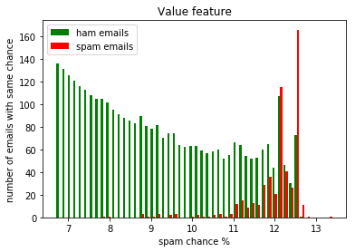

```python
hamValueBayesianPs = [valueBayesian(feature) for feature in hamValues]
spamValueBayesianPs = [valueBayesian(feature) for feature in spamValues]

plt.hist([hamValueBayesianPs,spamValueBayesianPs], 50, color = ['g','r'], label = ['ham emails','spam emails'])
plt.title('Value feature')
plt.xlabel('spam chance %')
plt.ylabel('number of emails with same chance')
plt.legend()
plt.show()
```

همانطور که بر روی نمودار مشخص است این ویژگی بهتر از ویژگی های قبلی اسپم بودن را تشخیص می دهد.

بد نیست احتمال های بدست آمده از هر ویژگی را در کنار هم رسم کنیم:

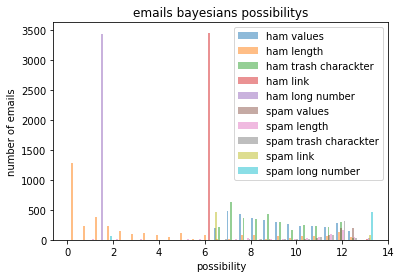

```python
hamBayesiansPs = [hamValueBayesianPs,hamLengthBayesianPs,hamTrashWeightsBayesianPs,hamLinkBayesianPs,hamLongNumberBayesianPs]
spamBayesiansPs = [spamValueBayesianPs,spamLengthBayesianPs,spamTrashWeightsBayesianPs,spamLinkBayesianPs,spamLongNumberBayesianPs]

hamLabels = ['ham values','ham length','ham trash charackter','ham link','ham long number']
spamLabels = ['spam values','spam length','spam trash charackter','spam link','spam long number']

plt.hist(hamBayesiansPs, 25, alpha=0.5, label = hamLabels)
plt.hist(spamBayesiansPs, 25, alpha=0.5, label = spamLabels)
plt.title('emails bayesians possibilitys')
plt.xlabel('possibility')
plt.ylabel('number of emails')
plt.legend()
plt.show()
```

اگر میانگین این احتمال ها را محاسبه کنیم به نتایج بهتری خواهیم رسید:

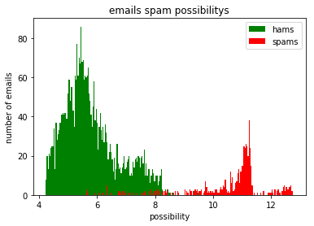

```python
def avgOfFiveFeature(a, b, c, d, e, n) :
    return [(a[i]+b[i]+c[i]+d[i]+e[i])/5  for i in range(n)]

hamsAvgOfFiveFeature = avgOfFiveFeature(hamValueBayesianPs, hamLengthBayesianPs, hamTrashWeightsBayesianPs, hamLinkBayesianPs, hamLongNumberBayesianPs, hamsNumber)
spamsAvgOfFiveFeature = avgOfFiveFeature(spamValueBayesianPs, spamLengthBayesianPs, spamTrashWeightsBayesianPs, spamLinkBayesianPs, spamLongNumberBayesianPs, spamsNumber)

plt.hist(hamsAvgOfFiveFeature, 200, color = 'g', label = 'hams')
plt.hist(spamsAvgOfFiveFeature, 200, color = 'r', label = 'spams')
plt.title('emails spam possibilitys')
plt.xlabel('possibility')
plt.ylabel('number of emails')
plt.legend()
plt.show()
```

پس در نهایت به احتمال مطلوبی می رسیم. اما کافی نیست و هنوز یک ویژگی بزرگ را اعمال نکردیم.

به عنوان ویژگی آخر کوله ی لغات را به روش معمول آن پیاده سازی خواهیم کرد و برای ترکیب احتمال لغات میانگین آن ها را استفاده خواهیم کرد:

```python
wordsRepeatInSpams = dict()
wordsRepeatInHams = dict()
wordsNumberOfHams = 0
wordsNumberOfSpams = 0

def updateWordsRepeat(emails, wordsRepeat, status) :
    global wordsNumberOfHams, wordsNumberOfSpams
    for email in emails :
        for word in email.split() :
            if len(word) < 2 : continue
            word = WordNetLemmatizer().lemmatize(word,'v')
            word = singularize(word)
            if word not in wordsRepeat :
                wordsRepeat[word] = 0
            wordsRepeat[word] += 1
            if status == 'ham' : wordsNumberOfHams += 1
            else : wordsNumberOfSpams += 1

updateWordsRepeat(hamEmails, wordsRepeatInHams, 'ham')
updateWordsRepeat(spamEmails, wordsRepeatInSpams, 'spam')
```

مانند محاسبه ارزش لغات اینجا هم در ابتدا حذف لغات پرتکرار را امتحان کردیم اما باز هم نتیجه ی خوبی نگرفتیم پس این موضوع را باز هم اعمال نمی کنیم.

```python
def deleteCommonWords(wordsRepeat, totalWordsNumber) :
    readyToRemove = set()
    for word in wordsRepeat :
        if wordsRepeat[word] >= totalWordsNumber/100 :
            readyToRemove.add(word)
    for word in readyToRemove :
        wordsRepeat.pop(word)

# deleteCommonWords(wordsRepeatInHams, wordsNumberOfHams)
# deleteCommonWords(wordsRepeatInSpams, wordsNumberOfSpams)
```

```python
def wordsBagBayesian(word) :
    P_spam = spamsNumber/(spamsNumber+hamsNumber)
    P_feature_if_spam = wordsRepeatInSpams[word] / wordsNumberOfSpams if word in wordsRepeatInSpams else 0
    P_feature_if_ham = wordsRepeatInHams[word] / wordsNumberOfHams if word in wordsRepeatInHams else 0
    P_feature = P_feature_if_spam + P_feature_if_ham
    return 100*(P_feature_if_spam * P_spam) / P_feature if P_feature != 0 else 0
```

```python
def emailWordsBagBayesian(words) :
    emailWordsBagBayes = 0
    wordsCount = 0
    for word in words :
        if len(word) < 2 : continue
        word = WordNetLemmatizer().lemmatize(word,'v')
        word = singularize(word)
        emailWordsBagBayes += wordsBagBayesian(word)
        wordsCount += 1
    return emailWordsBagBayes / wordsCount if wordsCount != 0 else 0
```

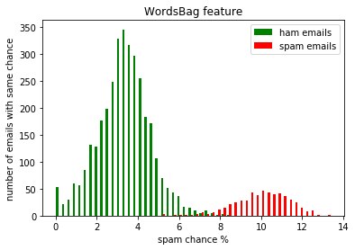

```python
hamWordsBagBayesianPs = [emailWordsBagBayesian(email.split()) for email in hamEmails]
spamWordsBagBayesianPs = [emailWordsBagBayesian(email.split()) for email in spamEmails]

plt.hist([hamWordsBagBayesianPs,spamWordsBagBayesianPs], 50, color = ['g','r'], label = ['ham emails','spam emails'])
plt.title('WordsBag feature')
plt.xlabel('spam chance %')
plt.ylabel('number of emails with same chance')
plt.legend()
plt.show()
```

همانطور که مشاهده می کنید این ویژگی بازده به شدت بهتری نسبت به ویژگی های قبلی دارد و تقریبا به تنهایی با ترکیب آنها برابری می کنید. پس به این ویژگی اثری هم ارز ترکیب آنها می دهیم و میانگین همه را به عنوان شانس نهایی اسپم بودن درنظر می گیریم:

```python
def chanceFormol(value, wordsBag, length, trashNumber, link, longNumber) :
    return (wordsBag + (value + length + trashNumber + link + longNumber)/5)/2
```

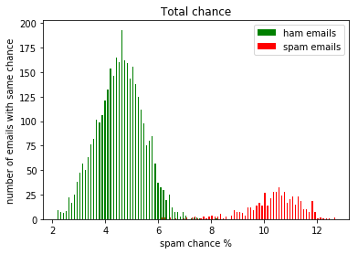

```python
def hamEmailsSpamChance(index) :
    return chanceFormol(hamValueBayesianPs[index], hamWordsBagBayesianPs[index], hamLengthBayesianPs[index], hamTrashWeightsBayesianPs[index], hamLinkBayesianPs[index], hamLongNumberBayesianPs[index])
def spamEmailsSpamChance(index) :
    return chanceFormol(spamValueBayesianPs[index], spamWordsBagBayesianPs[index], spamLengthBayesianPs[index], spamTrashWeightsBayesianPs[index], spamLinkBayesianPs[index], spamLongNumberBayesianPs[index])

hamEmailsSpamChances = [hamEmailsSpamChance(index) for index in range(hamsNumber)]
spamEmailsSpamChances = [spamEmailsSpamChance(index) for index in range(spamsNumber)]

plt.hist([hamEmailsSpamChances,spamEmailsSpamChances], 100, color = ['g','r'], label = ['ham emails','spam emails'])
plt.title('Total chance')
plt.xlabel('spam chance %')
plt.ylabel('number of emails with same chance')
plt.legend()
plt.show()
```

به نظر رضایت بخش می رسد!

حال بهید تصمیم بگیریم برای گرفتن بازده حداکثری چه احتمالی را مرز اسپم بودن درنظر بگیریم. پس ایم بازده را برای تمام مرز ها با دقت صدم درصد محاسبه می کنیم و بهترین مرز را انتخاب می کنیم:

```
max edge (max spam chance) : 13
```

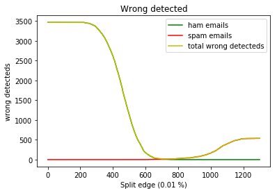

```python
maxEdge = math.floor(max(max(hamEmailsSpamChances), max(spamEmailsSpamChances))) + 1
print('max edge (max spam chance) :', maxEdge)

def wrongDetected(edge, status) :
    wrongs = 0
    if status == 'ham' :
        for chance in hamEmailsSpamChances :
            if chance >= edge :
                wrongs += 1
    else :
        for chance in spamEmailsSpamChances :
            if chance < edge :
                wrongs += 1
    return wrongs

wrongHamDetectedSpams = [wrongDetected(edge/100, 'ham') for edge in range(100*maxEdge+1)]
wrongSpamDetectedHams = [wrongDetected(edge/100, 'spam') for edge in range(100*maxEdge+1)]
def totalWrongDetected(index) :
    return wrongHamDetectedSpams[index] + wrongSpamDetectedHams[index]

plt.plot(wrongHamDetectedSpams, color = 'g', label = 'ham emails')
plt.plot(wrongSpamDetectedHams, color = 'r', label = 'spam emails')
plt.plot([totalWrongDetected(index) for index in range(100*maxEdge+1)], color = 'y', label = 'total wrong detecteds')
plt.title('Wrong detected')
plt.xlabel('Split edge (0.01 %)')
plt.ylabel('wrong detecteds')
plt.legend()
plt.show()
```

این نمودار تعداد کلی تشخیص های اشتباه است اما متن پروژه به ما معیار های دقیق تری داده است که لازم است آن ها را بیشینه کنیم.

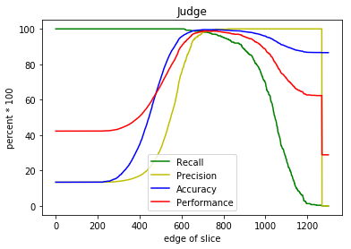

```python
def correctDetectedSpams(index) :
    return spamsNumber - wrongSpamDetectedHams[index]
def detectedSpams(index) :
    return spamsNumber - wrongSpamDetectedHams[index] + wrongHamDetectedSpams[index]
def correctDetected(index) :
    return hamsNumber + spamsNumber - totalWrongDetected(index)

def recall(index) :
    return 100*correctDetectedSpams(index)/spamsNumber
def precision(index) :
    return 100*correctDetectedSpams(index)/detectedSpams(index) if detectedSpams(index) != 0 else 0
def accuracy(index) :
    return 100*correctDetected(index)/emailsNumber

recalls = [recall(index) for index in range(100*maxEdge+1)]
precisions = [precision(index) for index in range(100*maxEdge+1)]
accuracys = [accuracy(index) for index in range(100*maxEdge+1)]
performances = [(recalls[index]+precisions[index]+accuracys[index])/3 for index in range(100*maxEdge+1)]

plt.plot(recalls, color = 'g', label = 'Recall')
plt.plot(precisions, color = 'y', label = 'Precision')
plt.plot(accuracys, color = 'b', label = 'Accuracy')
plt.plot(performances, color = 'r', label = 'Performance')
plt.title('Judge')
plt.xlabel('edge of slice')
plt.ylabel('percent * 100')
plt.legend()
plt.show()
```

```python
bestPerformances = max(performances)
edgeOfSlice = performances.index(bestPerformances) / 100
print('best performance : %', bestPerformances, ', for edge : ', edgeOfSlice)
```

```
best performance : % 98.87160844937603 , for edge :  7.05
```

پس بهترین مرز جداسازی در ۷.۰۵ رخ می دهد که درصد تشخیص ما را به 98.87 می رساند.

حال می توانیم با دانستن مرز جداسازی رابطه ی ساده ی رای نهایی را بنویسیم:

```python
def isSpam(chance) :
    if chance >= edgeOfSlice : return True
    else : False
```

## overfit :

خب حالا که الگوریتم تشخیص ما به پایان رسیده باید کارآمدی آن را بر روی دیتای تستی که کنار گذاشتیم بررسی کنیم تا از رخ ندادن اوورفیت مطمین شویم.

تمام مراحلی که برای محاسبه ی احتمال نهایی اسپم بودن طی کردیم را باید اینبار بر روی دیتای تست تکرار کنیم:

```python
testFile = './data/test.csv'
testData = pd.read_csv(testFile)

testEmails = testData['text']
testStatuses = testData['type']
testNumber = len(testEmails)
```

```python
testHasLinks = [hasLink(testEmails[index]) for index in range(testNumber)]
testHasLongNumber = [hasLongNumber(testEmails[index]) for index in range(testNumber)]
testTrashCharsWeights = [0 for i in range(testNumber)]

for index in range(testNumber) :
    email = testEmails[index].lower()
    formedEmail = ""
    for character in email :
        if character >= 'a' and character <= 'z' :
            formedEmail += character
        else :
            formedEmail += ' '
            testTrashCharsWeights[index] += 1
    testTrashCharsWeights[index] /= len(testEmails[index].split()) if testTrashCharsWeights[index] != 0 else 1
    testEmails[index] = formedEmail

testEmailValues = setEmailsValue(testEmails)
testEmailLengths = [len(email) for email in testEmails]
```

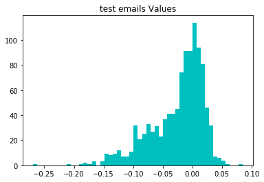

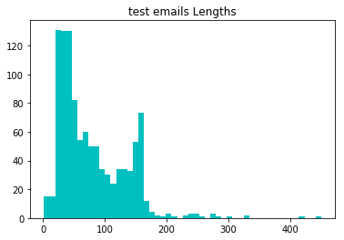

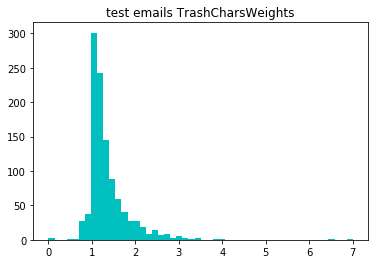

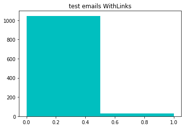

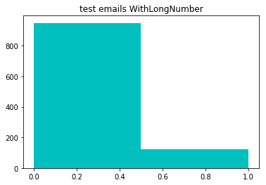

```python
plt.hist(testEmailValues, 50, color = 'c')
plt.title('test emails Values')
plt.show()
plt.hist(testEmailLengths, 50, color = 'c')
plt.title('test emails Lengths')
plt.show()
plt.hist(testTrashCharsWeights, 50, color = 'c')
plt.title('test emails TrashCharsWeights')
plt.show()
plt.hist(testHasLinks, 2, color = 'c')
plt.title('test emails WithLinks')
plt.show()
plt.hist(testHasLongNumber, 2, color = 'c')
plt.title('test emails WithLongNumber')
plt.show()
```

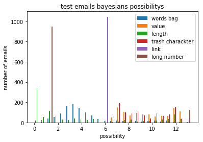

```python
testValuesBayesianPs = [valueBayesian(feature) for feature in testEmailValues]
testLengthsBayesianPs = [lengthBayesian(feature) for feature in testEmailLengths]
testTrashCharsBayesianPs = [trashCharBayesian(feature) for feature in testTrashCharsWeights]
testLinksBayesianPs = [linkBayesian(feature) for feature in testHasLinks]
testLongNumberBayesianPs = [longNumberBayseian(feature) for feature in testHasLongNumber]
testWordsBagBayesianPs = [emailWordsBagBayesian(email.split()) for email in testEmails]

testBayesiansPs = [testWordsBagBayesianPs,testValuesBayesianPs,testLengthsBayesianPs,testTrashCharsBayesianPs,testLinksBayesianPs,testLongNumberBayesianPs]
labels = ['words bag','value','length','trash charackter','link','long number']

plt.hist(testBayesiansPs, 25, label = labels)
plt.title('test emails bayesians possibilitys')
plt.xlabel('possibility')
plt.ylabel('number of emails')
plt.legend()
plt.show()
```

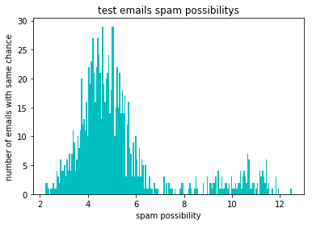

```python
testSpamChances = [chanceFormol(testValuesBayesianPs[index], testWordsBagBayesianPs[index], testLengthsBayesianPs[index], testTrashCharsBayesianPs[index], testLinksBayesianPs[index], testLongNumberBayesianPs[index]) for index in range(testNumber)]

plt.hist(testSpamChances, 200, color = 'c')
plt.title('test emails spam possibilitys')
plt.xlabel('spam possibility')
plt.ylabel('number of emails with same chance')
plt.show()
```

```python
thdah = thdas = tsdah = tsdas = 0
# t : test, d : detected, a : as, h : ham, s : spam

for index in range(testNumber) :
    if testStatuses[index] == 'ham' :
        if isSpam(testSpamChances[index]) :
            thdas += 1
        else :
            thdah += 1
    else :
        if isSpam(testSpamChances[index]) :
            tsdas += 1
        else :
            tsdah += 1

testRecall = tsdas / (tsdah + tsdas) if tsdah + tsdas != 0 else 0
testPrecision = tsdas / (thdas + tsdas) if thdas + tsdas != 0 else 0
testAccuracy = (thdah + tsdas) / testNumber
testPerformance = 100*(testRecall + testPrecision + testAccuracy)/3

print('Racall :', testRecall)
print('Precision :', testPrecision)
print('Accuracy :', testAccuracy)
print('Performance: %', testPerformance)
```

```
Racall : 0.9714285714285714
Precision : 0.9577464788732394
Accuracy : 0.9906803355079217
Performance: % 97.32851286032444
```

پس همانطور که مشاهده می کنید درصد بازده این الگوریتم بر روی دیتای تست اختلاف زیادی با دیتای آموزش ندارد و این نشانه ی عدم وجود اوورفیت می باشد.

پس الگوریتم مناسبی برای هدفی که داشتیم پیدا کردیم و می توانیم آن را برای دریافت خروجی بازنویسی کنیم.